# Missing Data

Lucy D’Agostino McGowan

## Visualizing missingness

```r
library(visdat)
vis_dat(nhanes)
```

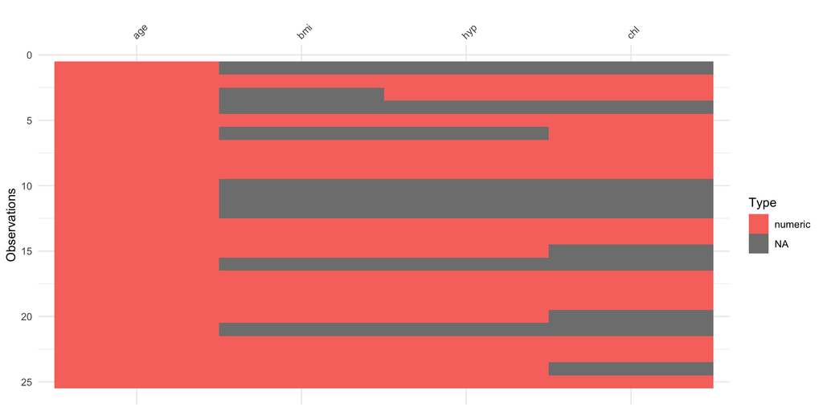

## Application Exercise

1. `install.packages("visdat")`
2. Load the causaldata package and use the `vis_dat()` function to examine the `nhefs` data frame
3. Fit a linear model predicting `pregnancies` from `birthcontrol`

`05:00`

## Types of Missing Data

### Missing completely at random

The probability a variable is missing is the same for all observations

### Missing at random

The probability a variable is missing depends only on available information (the other variables)

### Missing not at random

The probability a variable is missing depends on external factors

## Imputation

Impute the mean/median or most common value for all missing variable

- Use the observed variables to create a *model* to predict what the missing value would be
- Use the observed variables to create many *models* to predict what the missing value would be (multiple imputation)

## Predictive mean matching

- Variable A has some missing values
- Calculates the predicted value of A for all observations using the other measured variables
- For observation i, finds the set of observations that have the closest predicted value for variable A
- Randomly select one of the non-missing values of A from this set for the missing observation

## Example

```r
library(visdat)
vis_dat(nhanes)
```

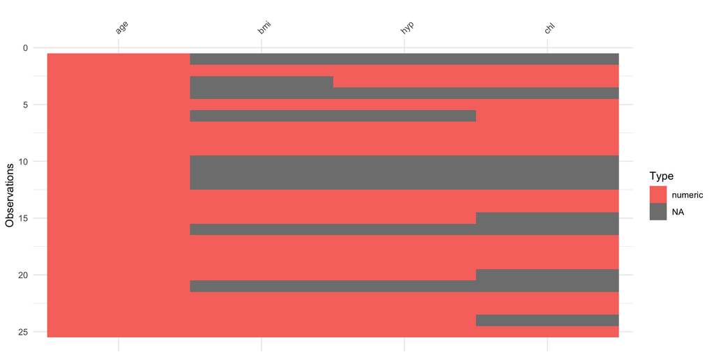

## Predictive mean matching

```r
library(mice)
set.seed(1)
nhanes_imp <- mice(nhanes, m = 1, method = "pmm")
```

## Predictive mean matching

```r
nhanes_imp$imp$bmi
```

```
      1
1  29.6
3  27.2
4  20.4
6  25.5
10 21.7
11 22.0
12 22.7
16 26.3
21 30.1
```

```r
nhanes |>
  filter(bmi == 29.6)
```

```
   age  bmi hyp chl
15   1 29.6   1  NA
```

## Predictive mean matching

```r
complete(nhanes_imp)
```

```
   age  bmi hyp chl
1    1 29.6   1 131
2    2 22.7   1 187
3    1 27.2   1 187
4    3 20.4   2 204
5    1 20.4   1 113
6    3 25.5   2 184
7    1 22.5   1 118
8    1 30.1   1 187
9    2 22.0   1 238
10   2 21.7   2 131
11   1 22.0   1 187
12   2 22.7   1 187
13   3 21.7   1 206
14   2 28.7   2 204
15   1 29.6   1 187
16   1 26.3   1 187
17   3 27.2   2 284
18   2 26.3   2 199
19   1 35.3   1 218
20   3 25.5   2 218
21   1 30.1   1 187
22   1 33.2   1 229
23   1 27.5   1 131
24   3 24.9   1 284
25   2 27.4   1 186
```

## Application Exercise

1. `install.packages("mice")`
2. Use the `mice()` function to create a single imputed dataset of the `nhefs` data using predictive mean matching
3. Fit a linear model predicting `pregancies` from `birthcontrol` on the imputed dataset
4. Explore the help files for `?mice`. What types of univariate imputation methods are included?

`08:00`

## Multiple imputation

```r
set.seed(1)
nhanes_imp <- mice(nhanes,
                   m = 5,
                   method = "pmm")
```

## Multiple imputation

```r
nhanes_imp$imp$bmi
```

```
      1    2    3    4    5
1  27.2 35.3 27.2 29.6 24.9
3  28.7 27.2 35.3 30.1 29.6
4  25.5 20.4 22.0 20.4 25.5
6  24.9 21.7 22.7 24.9 27.4
10 28.7 22.7 20.4 20.4 22.7
11 30.1 29.6 35.3 22.7 29.6
12 22.0 27.2 26.3 27.4 22.5
16 22.0 27.2 35.3 22.7 24.9
21 26.3 29.6 27.2 29.6 27.2
```

## Multiple imputation

```r
complete(nhanes_imp, 1)
```

```
   age  bmi hyp chl
1    1 27.2   1 199
2    2 22.7   1 187
3    1 28.7   1 187
4    3 25.5   1 218
5    1 20.4   1 113
6    3 24.9   1 184
7    1 22.5   1 118
8    1 30.1   1 187
9    2 22.0   1 238
10   2 28.7   1 206
11   1 30.1   1 199
12   2 22.0   1 187
13   3 21.7   1 206
14   2 28.7   2 204
15   1 29.6   1 206
16   1 22.0   1 187
17   3 27.2   2 284
18   2 26.3   2 199
19   1 35.3   1 218
20   3 25.5   2 199
21   1 26.3   1 229
22   1 33.2   1 229
23   1 27.5   1 131
24   3 24.9   1 206
25   2 27.4   1 186
```

## Multiple imputation

```r
complete(nhanes_imp, 2)
```

```
   age  bmi hyp chl
1    1 35.3   1 284
2    2 22.7   1 187
3    1 27.2   1 187
4    3 20.4   1 118
5    1 20.4   1 113
6    3 21.7   2 184
7    1 22.5   1 118
8    1 30.1   1 187
9    2 22.0   1 238
10   2 22.7   1 187
11   1 29.6   1 206
12   2 27.2   1 199
13   3 21.7   1 206
14   2 28.7   2 204
15   1 29.6   1 186
16   1 27.2   1 184
17   3 27.2   2 284
18   2 26.3   2 199
19   1 35.3   1 218
20   3 25.5   2 218
21   1 29.6   1 204
22   1 33.2   1 229
23   1 27.5   1 131
24   3 24.9   1 238
25   2 27.4   1 186
```

## Multiple imputation

```r
complete(nhanes_imp, 3)
```

```
   age  bmi hyp chl
1    1 27.2   1 187
2    2 22.7   1 187
3    1 35.3   1 187
4    3 22.0   1 184
5    1 20.4   1 113
6    3 22.7   2 184
7    1 22.5   1 118
8    1 30.1   1 187
9    2 22.0   1 238
10   2 20.4   1 187
11   1 35.3   2 184
12   2 26.3   1 206
13   3 21.7   1 206
14   2 28.7   2 204
15   1 29.6   1 229
16   1 35.3   2 187
17   3 27.2   2 284
18   2 26.3   2 199
19   1 35.3   1 218
20   3 25.5   2 206
21   1 27.2   1 131
22   1 33.2   1 229
23   1 27.5   1 131
24   3 24.9   1 284
25   2 27.4   1 186
```

## Multiple imputation

```r
complete(nhanes_imp, 4)
```

```
   age  bmi hyp chl
1    1 29.6   1 187
2    2 22.7   1 187
3    1 30.1   1 187
4    3 20.4   1 187
5    1 20.4   1 113
6    3 24.9   1 184
7    1 22.5   1 118
8    1 30.1   1 187
9    2 22.0   1 238
10   2 20.4   1 238
11   1 22.7   1 131
12   2 27.4   2 184
13   3 21.7   1 206
14   2 28.7   2 204
15   1 29.6   1 229
16   1 22.7   1 113
17   3 27.2   2 284
18   2 26.3   2 199
19   1 35.3   1 218
20   3 25.5   2 184
21   1 29.6   1 206
22   1 33.2   1 229
23   1 27.5   1 131
24   3 24.9   1 199
25   2 27.4   1 186
```

## Multiple imputation

```r
complete(nhanes_imp, 5)
```

```
   age  bmi hyp chl
1    1 24.9   1 238
2    2 22.7   1 187
3    1 29.6   1 187
4    3 25.5   2 238
5    1 20.4   1 113
6    3 27.4   1 184
7    1 22.5   1 118
8    1 30.1   1 187
9    2 22.0   1 238
10   2 22.7   1 187
11   1 29.6   1 206
12   2 22.5   1 187
13   3 21.7   1 206
14   2 28.7   2 204
15   1 29.6   1 206
16   1 24.9   1 238
17   3 27.2   2 284
18   2 26.3   2 199
19   1 35.3   1 218
20   3 25.5   2 187
21   1 27.2   1 187
22   1 33.2   1 229
23   1 27.5   1 131
24   3 24.9   1 218
25   2 27.4   1 186
```

## Application Exercise

1. Use the `mice()` function to create a 5 imputed datasets of the `nhefs` data using predictive mean matching
2. Fit a linear model predicting `pregnancies` from `birthcontrol` on each of the 5 imputed datasets

`08:00`

## Pool Results

```r
fit <- with(data = nhanes_imp, lm(age ~ bmi))
```

## Pool Results

```r
fit <- with(data = nhanes_imp, lm(age ~ bmi))
fit
```

```
call :
with.mids(data = nhanes_imp, expr = lm(age ~ bmi))

call1 :
mice(data = nhanes, m = 5, method = "pmm")

nmis :
[1]  0  9  8 10

analyses :
[[1]]

Call:
lm(formula = age ~ bmi)

Coefficients:
(Intercept)          bmi
    3.71598     -0.07405


[[2]]

Call:
lm(formula = age ~ bmi)

Coefficients:
(Intercept)          bmi
     4.5686      -0.1054


[[3]]

Call:
lm(formula = age ~ bmi)

Coefficients:
(Intercept)          bmi
    4.28034     -0.09311


[[4]]

Call:
lm(formula = age ~ bmi)

Coefficients:
(Intercept)          bmi
    3.84211     -0.07974


[[5]]

Call:
lm(formula = age ~ bmi)

Coefficients:
(Intercept)          bmi
    3.74803     -0.07538
```

## Pool Results

```r
fit <- with(data = nhanes_imp, lm(age ~ bmi))
pool(fit)
```

```
Class: mipo    m = 5
         term m    estimate        ubar            b           t dfcom       df
1 (Intercept) 5  4.03102333 1.069419646 0.1415549368 1.239285570    23 16.86913
2         bmi 5 -0.08554488 0.001494635 0.0001806221 0.001711381    23 17.25864
        riv    lambda       fmi
1 0.1588394 0.1370676 0.2239293
2 0.1450164 0.1266501 0.2128701
```

## Pool Results

```r
with(data = nhanes_imp, lm(age ~ bmi)) |>
  pool() |>
  tidy()
```

```
         term    estimate  std.error statistic     p.value            b
1 (Intercept)  4.03102333 1.11323204  3.621009 0.002132875 0.1415549368
2         bmi -0.08554488 0.04136885 -2.067857 0.053982698 0.0001806221
        df dfcom       fmi    lambda m       riv        ubar
1 16.86913    23 0.2239293 0.1370676 5 0.1588394 1.069419646
2 17.25864    23 0.2128701 0.1266501 5 0.1450164 0.001494635
```

## Pooling effect estimates

$$\bar\theta = \frac{1}{m}\sum_{i=1}^m\theta_i$$

## Pooling standard errors

$$V_{Total} = V_{within} + V_{between} + \frac{V_{between}}{m}$$

“Rubin’s Rules”

## Pooling standard errors

$$V_{within} =\frac{1}{m}\sum_{i=1}^mSE_i^2$$

## Pooling standard errors

$$V_{between} =\frac{\sum_{i=1}^m(\theta_i-\bar{\theta})^2}{m-1}$$

## Application Exercise

1. Use the `with()` function to fit a model on each of your 5 imputed datasets.
2. Use the `pool()` function to pool the results. Compare to your previous results

`08:00`

## Adding in the PS weighting

- Create m imputed datasets
- Estimate the propensity score within each one
- Run a seperate outcome model for each propensity score, pool the results

## Adding in the PS weighting

```r
nhanes$exp <- rbinom(25, 1, 1 / (1 + exp(nhanes$age)))
nhanes_imp <- mice(nhanes, m = 5, method = "pmm")
```

## Add weights

```r
imp_list <- mice::complete(nhanes_imp, action = "all")

fit_model <- function(dat) {
  ps <- glm(exp ~ bmi + hyp + chl, data = dat, family = binomial)
  weights <- propensity::wt_ate(predict(ps, type = "response"), dat$exp, exposure_type = "binary", .treated = 1)

  model <- lm(age ~ bmi + exp + hyp + chl, data = dat, weights = weights)
  return(model)
}

results <- purrr::map(imp_list, fit_model)
pooled <- mice::pool(results)
summary(pooled) |>
  filter(term == "exp")
```

```
  term   estimate std.error  statistic       df   p.value
1  exp -0.1974552 0.2970822 -0.6646483 6.649815 0.5286409
```

## What goes into your imputation model?

- Your outcome **ALWAYS** for stochastic (multiple) imputation
- All predictors in your propensity score model
- All predictors in your outcome model
- [Optional] additional variables